# Prediciton Assignment - Practical Machine Learning

Oscar Reyes

July 25, 2015

# 1 Overview

Using devices such as Jawbone Up, Nike FuelBand, and Fitbit it is now possible to collect a large amount of data about personal activity relatively inexpensively. These type of devices are part of the quantified self movement – a group of enthusiasts who take measurements about themselves regularly to improve their health, to find patterns in their behavior, or because they are tech geeks. One thing that people regularly do is quantify how much of a particular activity they do, but they rarely quantify how well they do it. In this project, our goal will be to use data from accelerometers on the belt, forearm, arm, and dumbell of 6 participants. They were asked to perform barbell lifts correctly and incorrectly in 5 different ways. More information is available from the website here: http://groupware.les.inf.puc-rio.br/har (see the section on the Weight Lifting Exercise Dataset).

# 2 Data

| Type | Source |
| --- | --- |
| Training | https://d396qusza40orc.cloudfront.net/predmachlearn/pml-training.csv |
| Test | https://d396qusza40orc.cloudfront.net/predmachlearn/pml-testing.csv |
| **Source** | http://groupware.les.inf.puc-rio.br/har |

# 3 Objective

Predict the manner in which they did the exercise. This is the **“classe”** variable in the training set.

# 4 Project

## 4.1 Libraries

```r
# Loading Libraries
library (caret)
```

```r
library (ggplot2)
library (knitr)
library (lattice)
library (randomForest)
library (rattle)
library (RColorBrewer)
library (rpart)
library (rpart.plot)
set.seed(1234)
```

## 4.2 Loading Data

```r
##Loading Data
home = setwd(Sys.getenv("HOME"))

# Source Directory
swdMain <- "/Users/oreyesc"
swdSubDir <- "MachineLearningProject"
getswd <- getwd()

# URLs
trainingURL <- "https://d396qusza40orc.cloudfront.net/predmachlearn/pml-training.csv"
testingURL <- "https://d396qusza40orc.cloudfront.net/predmachlearn/pml-testing.csv"

# File names:
trainingfile <- "pml-training.csv"
testingfile <- "pml-testing.csv"


if (getswd != swdMain){
        if (!file.exists(swdMain)){
                dir.create(file.path(swdMain,
                                     swdSubDir),
                           showWarnings = FALSE)
        }

} else if (!file.exists(swdSubDir)){
        dir.create(file.path(swdSubDir),
                   showWarnings = FALSE)
}
setwd (file.path(swdMain, swdSubDir))

# Downloading the information:
if (!file.exists(trainingfile)){
        download.file(url = trainingURL,
                      destfile = trainingfile,
                      method = "curl")
}
if (!file.exists(testingfile)){
        download.file(url = testingURL,
                      destfile = testingfile,
                      method = "curl")
}
# Loading information from files:
trainingData <- read.csv(trainingfile,
                         row.names = 1,
                         header = TRUE,
                         sep = ",",
                         na.strings = c("NA",
                                        "#DIV/0!",
                                        ""))

testingData <- read.csv(testingfile,
                        row.names = 1,
                        header = TRUE,
                        sep = ",",
                        na.strings = c("NA",
                                       "#DIV/0!",
                                       ""))
trainingData <- trainingData[, -1]
```

## 4.3 Preprocessing Data

## 4.4 Creating Testing and Training Datasets

| Dataset | Percentage |
| --- | --- |
| **trainingData** | **100%** |
| training | 60% |
| testingTraining | 40% |

```r
#Datasets division
##Create data partitions from training dataset: training 60% and testing 40%
trainingDivision = createDataPartition(trainingData$classe,
                                       p = 0.60,
                                       list = FALSE)
training <- trainingData[trainingDivision, ]
testingTraining <- trainingData[-trainingDivision, ]
dim(training); dim(testingTraining)
```

```
## [1] 11776   158
```

```
## [1] 7846  158
```

## 4.5 Cleaning Data

1. Identify how may columns are with less than 60% of data:

```r
#Exploration & Cleaning
#Remove all information with less than 60% of fields filled
#Quantity of columns that have less than 60% of fields filled
sum((colSums(!is.na(training[,
                             -ncol(training)])) < 0.6 * nrow(training)))
```

```
## [1] 100
```

2. Select the columns with more than 60% of information:

```r
#Removing columns with poor data (less than 60%)
filledColumns <- c((colSums(!is.na(training[,
                                            -ncol(training)])) >= 0.6 * nrow(training)))
training <- training[,
                     filledColumns]
testingTraining <- testingTraining[, filledColumns]
dim(training)
```

```
## [1] 11776    58
```

```r
dim(testingTraining)
```

```
## [1] 7846   58
```

## 4.6 Model

### 4.6.1 Random Forest

`Random Forest` allow to stimate the `test set error` into the execution, so `cross-validation` or a `test set` are not required to obtain an unbiased estimete of `test set error`.

```r
#Random Forest Model
# Cross validation or separate test set is not required in random forest to obtain an unbiased estimate of the test set error.
# The test set error is evaluated by the aplication, on the execution.

randomForestModel <- randomForest(classe ~.,
                                  method = "rf",
                                  data = training,
                                  importance = TRUE)
print (randomForestModel)
```

```
##
## Call:
##  randomForest(formula = classe ~ ., data = training, method = "rf",      importance = TRUE)
##                Type of random forest: classification
##                      Number of trees: 500
## No. of variables tried at each split: 7
##
##         OOB estimate of  error rate: 0.22%
## Confusion matrix:
##      A    B    C    D    E  class.error
## A 3348    0    0    0    0 0.0000000000
## B    4 2275    0    0    0 0.0017551558
## C    0    7 2043    4    0 0.0053554041
## D    0    0    7 1921    2 0.0046632124
## E    0    0    0    2 2163 0.0009237875
```

#### 4.6.1.1 Evaluationg Random Forest Model - Random Forest

Verification of variable importance:

```r
#Evaluating the Model
# Variable importance measures:
importance(randomForestModel)
```

```
##                                A          B         C         D         E
## raw_timestamp_part_1 41.91770879 50.8961311 49.886498 40.535262 33.248252
## raw_timestamp_part_2  4.80923226  8.5582468  9.233540  6.604475  5.802909
## cvtd_timestamp       44.68480918 59.2055740 64.891142 64.457586 45.071206
## new_window            0.02149357  0.0155432 -1.184289 -1.347872  0.000000
## num_window           26.01716721 34.4387157 35.609356 27.462327 26.419521
## roll_belt            25.61268841 31.0582381 28.618085 36.078236 29.840147
## pitch_belt           20.55463951 29.1423914 26.954037 25.247937 21.614634
## yaw_belt             24.62168107 30.7366697 29.335813 30.756411 21.004949
## total_accel_belt     11.14865727 13.3151059 12.782686 11.948838 12.360529
## gyros_belt_x         11.16128349 10.1461467 12.943698 11.657261 11.494778
## gyros_belt_y          8.37540763 11.5969770 11.581148 12.177240 10.819082
## gyros_belt_z         13.27798386 16.4794716 17.535948 17.654369 16.737544
## accel_belt_x         10.91957234 14.6210370 14.248266 12.344112 11.971392
## accel_belt_y          9.46041839 10.9697231 10.583478 12.931735  9.674126
## accel_belt_z         17.30388262 18.5011111 18.714249 18.791280 16.063879
## magnet_belt_x        11.63445397 20.0071643 18.200924 15.313732 16.335541
## magnet_belt_y        16.18710679 19.4673090 20.924392 24.268725 19.282474
## magnet_belt_z        15.33324533 17.4691573 16.944239 23.256333 18.007738
## roll_arm             15.25970602 20.7542530 20.184383 19.035832 14.364666
## pitch_arm            11.60727086 17.2303386 15.363556 13.808980 11.921492
## yaw_arm              13.80436318 17.9607384 16.225792 17.112280 13.180612
## total_accel_arm       7.01169207 15.1758980 11.724179 10.895968 11.901620
## gyros_arm_x          12.45537444 15.6039889 13.608644 13.555574 11.871264
## gyros_arm_y          13.12188695 16.3828243 15.851732 16.179176 12.844839
## gyros_arm_z           7.72770465 11.4234397  9.704254  9.925335  7.804834
## accel_arm_x          12.22041853 12.0587610 12.328254 12.664488 10.272112
## accel_arm_y          11.79835382 14.7232903 13.721323 12.236621 11.953503
## accel_arm_z           8.94222140 13.9811061 14.511236 13.827395 12.448802
## magnet_arm_x         12.51848856 12.1905484 12.432547 11.650924 10.819409
## magnet_arm_y          9.42317040 13.1934603 13.589548 13.291948 10.547461
## magnet_arm_z         14.83675829 19.0126307 14.913420 15.313182 12.993138
## roll_dumbbell        16.95365091 20.4640215 23.143744 22.373099 18.245259
## pitch_dumbbell       10.26436739 13.8384247 14.049014 12.424750 11.543760
## yaw_dumbbell         13.30443679 19.2266505 18.126840 15.880455 14.385856
## total_accel_dumbbell 14.76299161 17.3269314 16.372616 15.823534 16.326331
## gyros_dumbbell_x     10.72129001 17.0917004 17.075934 13.530485 12.191874
## gyros_dumbbell_y     15.36616557 16.1712809 19.649598 16.283422 13.677112
## gyros_dumbbell_z     11.29909651 13.4976952 11.366777 11.091894  8.499182
## accel_dumbbell_x     13.58380852 17.0603503 17.619349 16.119235 14.514518
```

[output cut: 61 more lines]

```
## magnet_dumbbell_y               31.325681      325.2851886
## magnet_dumbbell_z               32.608793      294.5318557
## roll_forearm                    20.029776      234.9774862
## pitch_forearm                   27.941188      297.1432254
## yaw_forearm                     18.017069       53.1656419
## total_accel_forearm             16.454818       36.8498002
## gyros_forearm_x                 17.173957       25.8849914
## gyros_forearm_y                 24.438241       37.9910189
## gyros_forearm_z                 21.439981       27.1662054
## accel_forearm_x                 20.308395      133.3569173
## accel_forearm_y                 18.001828       44.6295458
## accel_forearm_z                 19.849596       93.2180296
## magnet_forearm_x                15.752232       74.7301961
## magnet_forearm_y                18.790117       67.2685092
## magnet_forearm_z                22.442968       90.0438560
```

#### 4.6.1.2 Confusion Matrix - Random Forest

```r
#Confusion Matrix
predictTraining <- predict(randomForestModel,
                           newdata = testingTraining[, -ncol(testingTraining)])
confusionMatrix(predictTraining,
                testingTraining$classe)
```

```
## Confusion Matrix and Statistics
##
##           Reference
## Prediction    A    B    C    D    E
##          A 2232    2    0    0    0
##          B    0 1516    4    0    0
##          C    0    0 1362    6    0
##          D    0    0    2 1279    0
##          E    0    0    0    1 1442
##
## Overall Statistics
##
##                Accuracy : 0.9981
##                  95% CI : (0.9968, 0.9989)
##     No Information Rate : 0.2845
##     P-Value [Acc > NIR] : < 2.2e-16
##
##                   Kappa : 0.9976
##  Mcnemar's Test P-Value : NA
##
## Statistics by Class:
##
##                      Class: A Class: B Class: C Class: D Class: E
## Sensitivity            1.0000   0.9987   0.9956   0.9946   1.0000
## Specificity            0.9996   0.9994   0.9991   0.9997   0.9998
## Pos Pred Value         0.9991   0.9974   0.9956   0.9984   0.9993
## Neg Pred Value         1.0000   0.9997   0.9991   0.9989   1.0000
## Prevalence             0.2845   0.1935   0.1744   0.1639   0.1838
## Detection Rate         0.2845   0.1932   0.1736   0.1630   0.1838
## Detection Prevalence   0.2847   0.1937   0.1744   0.1633   0.1839
## Balanced Accuracy      0.9998   0.9990   0.9973   0.9971   0.9999
```

#### 4.6.1.3 Validation - Random Forest

```r
#Accuracy validation
accuracyRandomForest <- c(as.numeric(predictTraining == testingTraining$classe))
accuracyRandomForest <- sum(accuracyRandomForest) * 100 / nrow(testingTraining)
accuracyRandomForest
```

```
## [1] 99.80882
```

```r
outOfSampleError <- 1 - accuracyRandomForest
```

[output not shown]

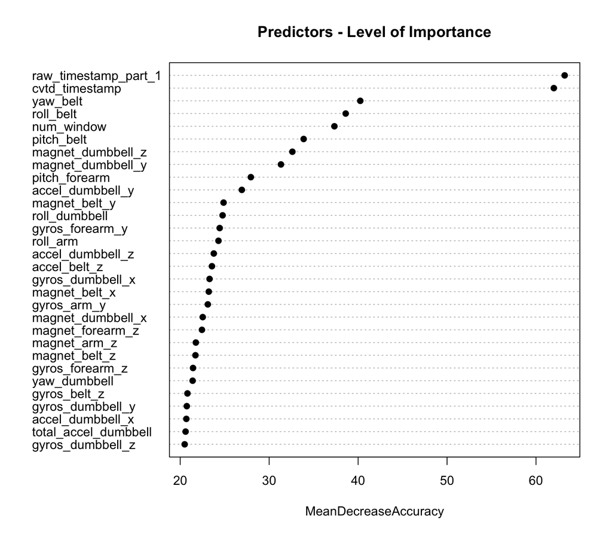

```r
importantVariable <- varImp(randomForestModel)$importance
varImpPlot(randomForestModel,
           sort = TRUE,
           type = 1,
           pch = 19,
           col = 1,
           cex = 1,
           main = "Predictors - Level of Importance")
```

### 4.6.2 Decision Tree

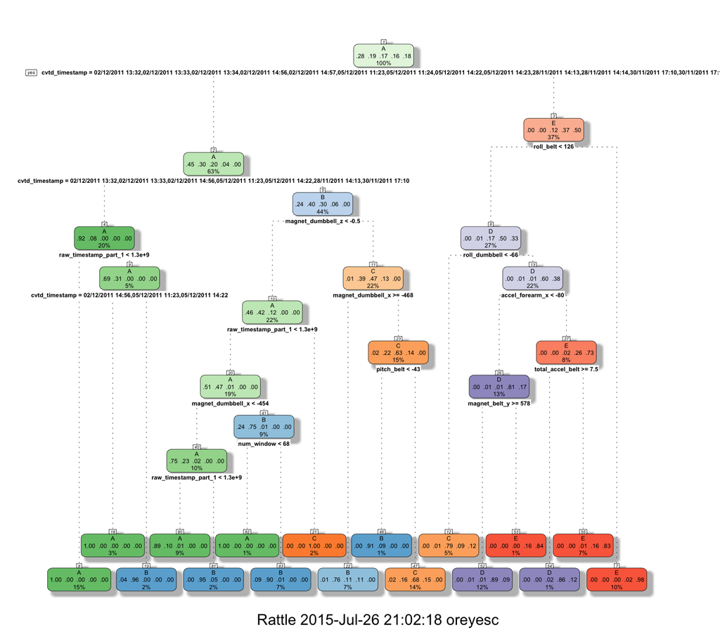

```r
#Decision Trees
decisionTree <- rpart(classe ~.,
                      data = training,
                      method = "class")
fancyRpartPlot(decisionTree)
```

```r
predictionDecisionTree <- predict(decisionTree,
                                   testingTraining,
                                   type = "class")

confusionMatrix(predictionDecisionTree,
                testingTraining$classe)
```

```
## Confusion Matrix and Statistics
##
##           Reference
## Prediction    A    B    C    D    E
##          A 2161   61    5    3    0
##          B   50 1271   95   64    0
##          C   21  177 1242  203   65
##          D    0    9   19  899   92
##          E    0    0    7  117 1285
##
## Overall Statistics
##
##                Accuracy : 0.8741
##                  95% CI : (0.8665, 0.8813)
##     No Information Rate : 0.2845
##     P-Value [Acc > NIR] : < 2.2e-16
##
##                   Kappa : 0.8407
##  Mcnemar's Test P-Value : NA
##
## Statistics by Class:
##
##                      Class: A Class: B Class: C Class: D Class: E
## Sensitivity            0.9682   0.8373   0.9079   0.6991   0.8911
## Specificity            0.9877   0.9670   0.9281   0.9817   0.9806
## Pos Pred Value         0.9691   0.8588   0.7272   0.8822   0.9120
## Neg Pred Value         0.9874   0.9612   0.9795   0.9433   0.9756
## Prevalence             0.2845   0.1935   0.1744   0.1639   0.1838
## Detection Rate         0.2754   0.1620   0.1583   0.1146   0.1638
## Detection Prevalence   0.2842   0.1886   0.2177   0.1299   0.1796
## Balanced Accuracy      0.9779   0.9021   0.9180   0.8404   0.9359
```

#### 4.6.2.1 Validation - Decisiont Tree

```r
accuracyDecisionTree <- c(as.numeric(predictionDecisionTree == testingTraining$classe))
accuracyDecisionTree <- sum(accuracyDecisionTree) * 100 / nrow(testingTraining)
accuracyDecisionTree
```

```
## [1] 87.4076
```

```r
outOfSampleErrorDT <- 100 - accuracyDecisionTree
outOfSampleErrorDT
```

```
## [1] 12.5924
```

| Model | Accuracy | Out Of Sample Error |
| --- | --- | --- |
| `Decision Tree` | **87.40%** | **12.5924%** |

### 4.6.3 Comparisson of Models

[output not shown]

`Random Forest Model` has a better accuracy level.

## 4.7 Predictions

Working with the `Random Model`, because has a better accuracy level:

```r
#Testing the Model
testingD <- testingData[, -1]
testingD <- testingD[,
                     filledColumns]
testingD <- testingD[,
                     -ncol(testingD)]
testing <- rbind(training[100, -58],
                 testingD)
row.names(testing) <- c(100, 1:20)

predictions <- predict(randomForestModel,
                       newdata = testing[-1, ])
```

# 5 Answers

The following function creates the files. If have a character vector with 20 predictions in order for the 20 problems.

```r
pml_write_files = function(x){
        n = length(x)
        for(i in 1:n){
                filename = paste0("./answers/problem_id_",i,".txt")
                write.table(x[i],file=filename,quote=FALSE,row.names=FALSE,col.names=FALSE)
        }
}
pml_write_files(predictions)
print (predictions)
```

```
##  1  2  3  4  5  6  7  8  9 10 11 12 13 14 15 16 17 18 19 20
##  B  A  B  A  A  E  D  B  A  A  B  C  B  A  E  E  A  B  B  B
## Levels: A B C D E
```

**GitHub Repo**: https://github.com/oreyesc/Project---Machine-Learning  
**RPubs**: http://rpubs.com/oreyesc/95547